# Notes on Hands-On Machine Learning with Scikit-Learn, Keras & Tensorflow

### Softmax (Multinomial Logistic) Regression

Logistic regression can be extended to multiple classes directly without having to train and combine multiple binary classifiers.

Softmax function, where K is number of classes, s(x) is the vector containing the scores of each class for the instance x and $\sigma(s(x))_k$ is the estimated probability that the instance x belongs to class k.

$$\^{p}_k = \sigma(s(x))_k = \frac{exp(s_k(x))}{\sum_{j=1}^K exp(s_j(x))}$$

**Softmax regression classifier prediction**

$$\^{y} = argmax_k \sigma(s(x)) = argmax_k s_k(x) = argmax_k ((\sigma^{(k)})^{\intercal}x)$$

**Cross-entropy cost function**

$$J(\sigma) = -\frac{1}{m}\sum_{i=1}^m \sum_{k=1}^K y^{(i)} log(\^{p}_k^{(i)})$$

Where $y_k^{(i)}$ is the target probability that the ith instance belongs to class k. It is either 0 or 1.

> Cross-entropy and entropy come from information theory (Claude Shannon), check out [this video](https://youtu.be/ErfnhcEV1O8) for more info.

```python
from wsgiref.simple_server import software_version


X = iris['data'][:, (2,3)] # petal length and width
y = iris['target']

softmax_reg = LogisticRegression(multi_class='multinomial', solver='lbfgs', C=10)
softmax_reg.fit(X, y)

print(softmax_reg.predict([[5,2]]))
softmax_reg.predict_proba([[5,2]])
```

```
[2]
```

```
array([[6.38014896e-07, 5.74929995e-02, 9.42506362e-01]])
```

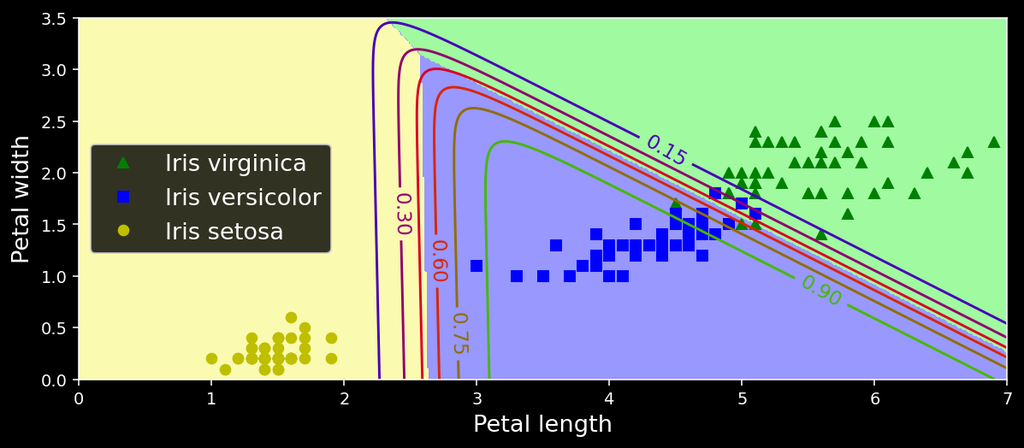

```python
x0, x1 = np.meshgrid(
        np.linspace(0, 8, 500).reshape(-1, 1),
        np.linspace(0, 3.5, 200).reshape(-1, 1),
    )
X_new = np.c_[x0.ravel(), x1.ravel()]


y_proba = softmax_reg.predict_proba(X_new)
y_predict = softmax_reg.predict(X_new)

zz1 = y_proba[:, 1].reshape(x0.shape)
zz = y_predict.reshape(x0.shape)

plt.figure(figsize=(10, 4))
plt.plot(X[y==2, 0], X[y==2, 1], "g^", label="Iris virginica")
plt.plot(X[y==1, 0], X[y==1, 1], "bs", label="Iris versicolor")
plt.plot(X[y==0, 0], X[y==0, 1], "yo", label="Iris setosa")

from matplotlib.colors import ListedColormap
custom_cmap = ListedColormap(['#fafab0','#9898ff','#a0faa0'])

plt.contourf(x0, x1, zz, cmap=custom_cmap)
contour = plt.contour(x0, x1, zz1, cmap=plt.cm.brg)
plt.clabel(contour, inline=1, fontsize=12)
plt.xlabel("Petal length", fontsize=14)
plt.ylabel("Petal width", fontsize=14)
plt.legend(loc="center left", fontsize=14)
plt.axis([0, 7, 0, 3.5])
plt.show()
```

## Support Vector Machines

Support vector machines are models particularly useful for small and medium size datasets. They can be used for linear and non-linear classification, regression and even outliers detection.

SVM try to fit the largest street between classes of the dataset. SVMs are **very sensitive to data scaling**.

### Margins

- A **Hard Margin** is when we don’t allow any misclassification and we force the classes to be separated entirely by the **support vectors of the classes** (i.e. the closest data points to the ‘street’ separating the classes). → this creates a very strict model that is **super susceptible to outliers**.
- A better tactic is to use a **Soft Margin** classifier, where we allow some mis-classification but we build a more robust model.

### Linear SVM

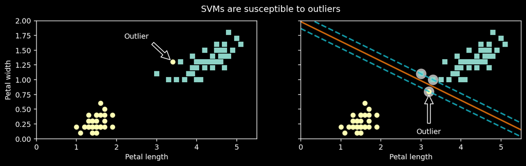

```python
from matplotlib import pyplot as plt
import numpy as np
from sklearn import datasets
from sklearn.pipeline import Pipeline
from sklearn.preprocessing import StandardScaler
from sklearn.svm import LinearSVC, SVC

plt.rcParams['figure.dpi'] = 140
plt.style.use('dark_background')

iris = datasets.load_iris()
X = iris["data"][:, (2, 3)]  # petal length, petal width
y = iris["target"]

setosa_or_versicolor = (y == 0) | (y == 1)
X = X[setosa_or_versicolor]
y = y[setosa_or_versicolor]

X_outliers = np.array([[3.4, 1.3], [3.2, 0.8]])
y_outliers = np.array([0, 0])

Xo1 = np.concatenate([X, X_outliers[:1]], axis=0)
yo1 = np.concatenate([y, y_outliers[:1]], axis=0)
Xo2 = np.concatenate([X, X_outliers[1:]], axis=0)
yo2 = np.concatenate([y, y_outliers[1:]], axis=0)

svm_clf1 = SVC(kernel="linear", C=10**9)
svm_clf1.fit(Xo2, yo2)

fig, axes = plt.subplots(1,2, figsize=(12,3), sharey=True)

axes[0].plot(Xo1[:, 0][yo1==1], Xo1[:, 1][yo1==1], "s")
axes[0].plot(Xo1[:, 0][yo1==0], Xo1[:, 1][yo1==0], "o")
axes[0].set_xlabel("Petal length")
axes[0].set_ylabel("Petal width")
axes[0].annotate("Outlier",
             xy=(X_outliers[0][0], X_outliers[0][1]),
             xytext=(2.5, 1.7),
             ha="center",
             arrowprops=dict(facecolor='black', shrink=0.1),
            )

axes[1].plot(Xo2[:, 0][yo2==1], Xo2[:, 1][yo2==1], "s")
axes[1].plot(Xo2[:, 0][yo2==0], Xo2[:, 1][yo2==0], "o")

axes[1].set_xlabel("Petal length")
axes[1].annotate("Outlier",
             xy=(X_outliers[1][0], X_outliers[1][1]),
             xytext=(3.2, 0.08),
             ha="center",
             arrowprops=dict(facecolor='black', shrink=0.1),
            )

for ax in axes:
    ax.set_ylim(0,2)
    ax.set_xlim(0,5.5)

w = svm_clf1.coef_[0]
b = svm_clf1.intercept_[0]

# At the decision boundary, w0*x0 + w1*x1 + b = 0
# => x1 = -w0/w1 * x0 - b/w1
x0 = np.linspace(0, 5.5, 200)
decision_boundary = -w[0]/w[1] * x0 - b/w[1]
margin = 1/w[1]

gutter_up = decision_boundary + margin
gutter_down = decision_boundary - margin

svs = svm_clf1.support_vectors_

axes[1].scatter(svs[:, 0], svs[:, 1], s=180, facecolors='#AAAAAA')
axes[1].plot(x0, decision_boundary, "-", linewidth=2, color='tab:orange', alpha=0.8)
axes[1].plot(x0, gutter_up, "--", linewidth=2, color='tab:cyan', alpha=0.8)
axes[1].plot(x0, gutter_down, "--", linewidth=2, color='tab:cyan', alpha=0.8)

fig.suptitle('SVMs are susceptible to outliers')
plt.show()
```

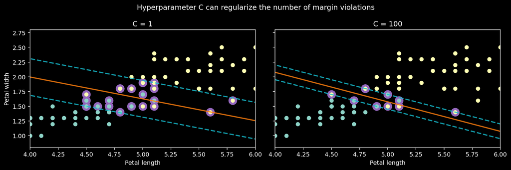

```python
iris = datasets.load_iris()
X = iris['data'][:, (2,3)] # petal length and width
y = (iris['target'] == 2).astype(np.float64) # select Iris virginica class

scaler = StandardScaler()

svm_clf1 = SVC(kernel = 'linear', C=1, random_state=42)
svm_clf2 = SVC(kernel = 'linear', C=100, random_state=42)

scaled_svm_clf1 = Pipeline([
        ("scaler", scaler),
        ("linear_svc", svm_clf1),
    ])
scaled_svm_clf2 = Pipeline([
        ("scaler", scaler),
        ("linear_svc", svm_clf2),
    ])

scaled_svm_clf1.fit(X, y)
scaled_svm_clf2.fit(X, y)

unscaled_svs_clf1 = scaler.inverse_transform(svm_clf1.support_vectors_)
unscaled_svs_clf2 = scaler.inverse_transform(svm_clf2.support_vectors_)

f, axes = plt.subplots(1,2, figsize=(12,4), sharey=True)

axes[0].scatter(unscaled_svs_clf1[:, 0], unscaled_svs_clf1[:, 1], facecolors='tab:purple', s=180)
axes[0].scatter(X[:,0][y==0], X[:,1][y==0])
axes[0].scatter(X[:,0][y==1], X[:,1][y==1])

axes[1].scatter(unscaled_svs_clf2[:, 0], unscaled_svs_clf2[:, 1], facecolors='tab:purple', s=180)
axes[1].scatter(X[:,0][y==0], X[:,1][y==0])
axes[1].scatter(X[:,0][y==1], X[:,1][y==1])

w1 = svm_clf1.coef_[0] / scaler.scale_
b1 = svm_clf1.decision_function([-scaler.mean_ / scaler.scale_])

# At the decision boundary, w0*x0 + w1*x1 + b = 0
# => x1 = -w0/w1 * x0 - b/w1
x0 = np.linspace(0, 10, 200)
decision_boundary1 = -w1[0]/w1[1] * x0 - b1/w1[1]
margin1 = 1/w1[1]
gutter_up1 = decision_boundary1 + margin1
gutter_down1 = decision_boundary1 - margin1

axes[0].plot(x0, decision_boundary1, "-", linewidth=2, color='tab:orange', alpha=0.8)
axes[0].plot(x0, gutter_up1, "--", linewidth=2, color='tab:cyan', alpha=0.8)
axes[0].plot(x0, gutter_down1, "--", linewidth=2, color='tab:cyan', alpha=0.8)
axes[0].set_ylabel('Petal width')

w2 = svm_clf2.coef_[0] / scaler.scale_
b2 = svm_clf2.decision_function([-scaler.mean_ / scaler.scale_])

decision_boundary2 = -w2[0]/w2[1] * x0 - b2/w2[1]
margin2 = 1/w2[1]
gutter_up2 = decision_boundary2 + margin2
gutter_down2 = decision_boundary2 - margin2

axes[1].plot(x0, decision_boundary2, "-", linewidth=2, color='tab:orange', alpha=0.8)
axes[1].plot(x0, gutter_up2, "--", linewidth=2, color='tab:cyan', alpha=0.8)
axes[1].plot(x0, gutter_down2, "--", linewidth=2, color='tab:cyan', alpha=0.8)

for ax in axes:
    ax.set_xlim(4, 6)
    ax.set_ylim(0.8, 2.8)
    ax.set_xlabel('Petal length')

axes[0].set_title('C = 1')
axes[1].set_title('C = 100')
f.suptitle('Hyperparameter C can regularize the number of margin violations')
plt.tight_layout()
plt.show()
```

SVM models don’t return probability for each class but simply the class itself.

```python
svm_clf = Pipeline([
    ('scaler', StandardScaler()),
    ('svm_classifier', LinearSVC(C = 1, loss = 'hinge'))
])

svm_clf.fit(X, y)
svm_clf.predict([[5.5, 1.7]])
```

```
array([1.])
```

### Nonlinear SVM Classification

Linear SVMs are very efficient and can be very valuable, however many dataset are not **linearly separable**. To work around this issue, we can transform our data introducing some non-linearity and then use a SVM to separate the classes.

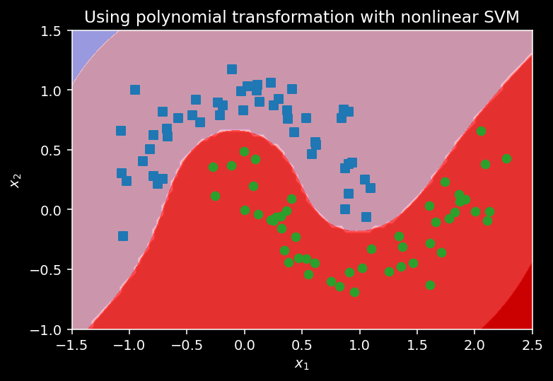

```python
from sklearn.datasets import make_moons
from sklearn.pipeline import Pipeline
from sklearn.preprocessing import PolynomialFeatures

X, y = make_moons(n_samples = 100, noise = 0.15)

poly_svm_clf = Pipeline([
    ('poly_features', PolynomialFeatures(degree = 3)),
    ('scaler', StandardScaler()),
    ('svm_classifier', LinearSVC(C = 10, loss = 'hinge')),
])

poly_svm_clf.fit(X, y)

x0s = np.linspace(-1.5, 2.5, 100)
x1s = np.linspace(-1.5, 2.5, 100)
x0, x1 = np.meshgrid(x0s, x1s)
X2 = np.c_[x0.ravel(), x1.ravel()]

y_pred = poly_svm_clf.predict(X2).reshape(x0.shape)
y_decision = poly_svm_clf.decision_function(X2).reshape(x0.shape)

plt.contourf(x0, x1, y_pred, cmap=plt.cm.seismic, alpha=0.8)
plt.contourf(x0, x1, y_decision, cmap=plt.cm.seismic, alpha=0.8)

plt.scatter(X[:, 0][y == 0], X[:, 1][y == 0], marker='s', color='tab:blue')
plt.scatter(X[:, 0][y == 1], X[:, 1][y == 1], color='tab:green')
plt.ylim(-1, 1.5)
plt.xlabel('$x_1$')
plt.ylabel('$x_2$')
plt.title('Using polynomial transformation with nonlinear SVM')
plt.show()
```